# Dogs Vs. Cats: Training a Covnet Using a Pretrained Model

Convolutional neural networks (CNN) are now one of the easiest and best machine learning methods to classify images. In this project, I have trained a CNN to classify whether an image is a picture of a cat or a dog.

The model is built using TensorFlow Keras, and mainly uses `Conv2D` layers and `MaxPooling2D` layers.

This notebook expands on the code in Chollet's *Deep Learning with Python* 2E.

```python
from tensorflow import keras
from tensorflow.keras import layers
import numpy as np
import matplotlib.pyplot as plt
```

## Download dataset

Training an image classification neural network takes *a lot* of computation power. Unfortunatly, my computer doesn't have quite enough oomph, so I have built this notebook to run in Google Colab.

Let's start by downloading the dataset from Kaggle, which provides us with 25,000 labeled images of cats and dogs.

```python
# In order to download from Kaggle, we need to provide our authenticaion JSON file.

from google.colab import files
files.upload()
```

```python
# Create the directory that Kaggle checks for the authentication key, move the JSON file to the proper location
!mkdir ~/.kaggle
!cp kaggle.json ~/.kaggle/

# Set permissions on the key
!chmod 600 ~/.kaggle/kaggle.json
!rm kaggle.json
```

```python
# Download the dataset from Kaggle, then unzip it.
!kaggle competitions download -c dogs-vs-cats

# Note that Google Colab uses an outdated Kaggle API (1.5.4) so the file downloaded is different than if you were to download it locally.
!unzip -q train.zip
!rm train.zip
```

```python
# Move the dataset to its own directory
!mkdir dogs-vs-cats-data
!cp -r train dogs-vs-cats-data
```

### Preview some of the images

To get an idea of the images we are working with, lets preview some of the images.

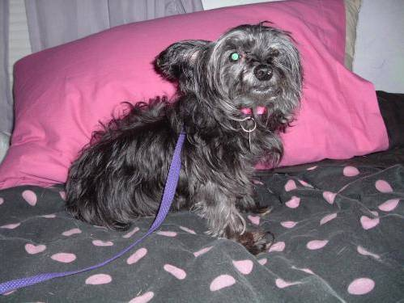

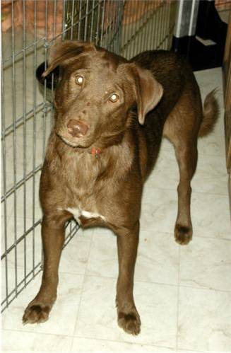

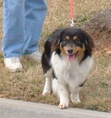

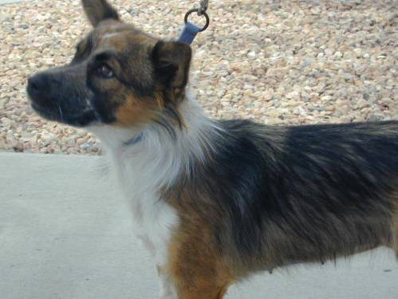

```python
from IPython.display import Image, display

# Display some Dogs
listOfImageNames = ['dogs-vs-cats-data/train/dog.0.jpg',
                    'dogs-vs-cats-data/train/dog.1.jpg',
                    'dogs-vs-cats-data/train/dog.2.jpg',
                    'dogs-vs-cats-data/train/dog.3.jpg']

for imageName in listOfImageNames:
    display(Image(filename=imageName))
```

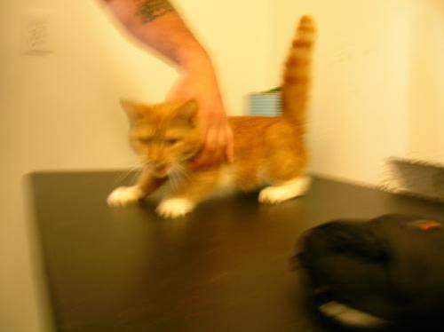

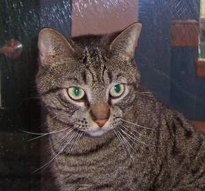

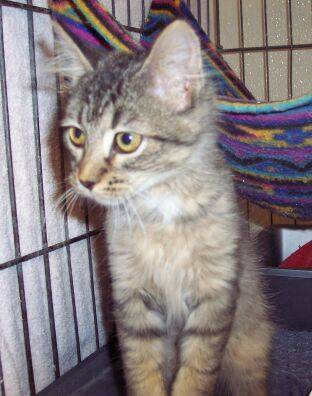

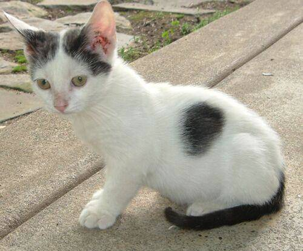

```python
# Display some Cats
listOfImageNames = ['dogs-vs-cats-data/train/cat.0.jpg',
                    'dogs-vs-cats-data/train/cat.1.jpg',
                    'dogs-vs-cats-data/train/cat.2.jpg',
                    'dogs-vs-cats-data/train/cat.3.jpg']

for imageName in listOfImageNames:
    display(Image(filename=imageName))
```

## Create training datasets

As of now, we have a directory of 25,000 images. We need a way to easily convert these to datasets that TensorFlow can handle.

Below is a small helper function that will use the file names of the images which contain the labels, and sort them into three directories:

- `train`
- `validation`
- `test`

And each directory will have a `dog` and `cat` sub-directory.

```python
import os
import shutil
import pathlib

# Our full data set is in the original data folder. Let's make a new small folder.
original_dir = pathlib.Path('dogs-vs-cats-data')
new_base_dir = pathlib.Path('dogs-vs-cats-small')

# Define a function to move our images to the new directory.
def make_subset(subset_name, start_index, end_index):
    for category in ('cat', 'dog'):
        dir = new_base_dir / subset_name / category
        pathlib.Path(dir).mkdir(parents=True, exist_ok=True)
        # images in the train set have the file name dog.5.jpg, with no leading zeros.
        fnames = [f'{category}.{i}.jpg' for i in range(start_index, end_index)]
        for fname in fnames:
            # Copy from original_dir to new_base_dir
            shutil.copyfile(src=original_dir / "train"/ fname, dst=dir / fname)

# Use Full Dataset
# Use 40% for training, 20% for validation, and reserve 40% as a test data set.
num_train_images = 10000
num_val_images = 5000
num_test_images = 10000

# Loop over the train, validation, and test sets, making subsets for each.
i = 0
for dataset, num_images in {"train":num_train_images, "validation":num_val_images, "test":num_test_images}.items():
    make_subset(dataset, i, int(i + num_images/2))
    i += int(num_images / 2)
```

Using the Preprocessing library from Keras, we can easily create a dataset from a directory, using the directory name as labels.

Also, let's format each image to a size of 250x250 pixels.

```python
# Create datasets from images
from tensorflow.keras.preprocessing import image_dataset_from_directory

train_dataset = image_dataset_from_directory(
    directory=new_base_dir / 'train',
    labels='inferred',
    image_size=(250, 250),
    batch_size=32)
validation_dataset = image_dataset_from_directory(
    directory=new_base_dir / 'validation',
    labels='inferred',
    image_size=(250, 250),
    batch_size=32)
test_dataset = image_dataset_from_directory(
    directory=new_base_dir / 'test',
    labels='inferred',
    image_size=(250, 250),
    batch_size=32)
```

```
Found 10000 files belonging to 2 classes.
Found 5000 files belonging to 2 classes.
Found 10000 files belonging to 2 classes.
```

## Construct the CNN Model

Training a CNN from scratch can yield decent results, but it turns out that we can utilize much larger pretrained models. In this project, we are using the VGG16 model as a base, and then building on top of that.

With the following construction, we will end up with feature maps of size 7x7 just before the `Flatten` Layer

```python
# Import the VGG16 Model
conv_base = keras.applications.vgg16.VGG16(
    weights='imagenet',
    include_top=False,
    input_shape=(250, 250, 3))
```

```
Downloading data from https://storage.googleapis.com/tensorflow/keras-applications/vgg16/vgg16_weights_tf_dim_ordering_tf_kernels_notop.h5
```

```python
conv_base.summary()
```

```
Model: "vgg16"
_________________________________________________________________
Layer (type)                 Output Shape              Param #
=================================================================
input_1 (InputLayer)         [(None, 250, 250, 3)]     0
_________________________________________________________________
block1_conv1 (Conv2D)        (None, 250, 250, 64)      1792
_________________________________________________________________
block1_conv2 (Conv2D)        (None, 250, 250, 64)      36928
_________________________________________________________________
block1_pool (MaxPooling2D)   (None, 125, 125, 64)      0
_________________________________________________________________
block2_conv1 (Conv2D)        (None, 125, 125, 128)     73856
_________________________________________________________________
block2_conv2 (Conv2D)        (None, 125, 125, 128)     147584
_________________________________________________________________
block2_pool (MaxPooling2D)   (None, 62, 62, 128)       0
_________________________________________________________________
block3_conv1 (Conv2D)        (None, 62, 62, 256)       295168
_________________________________________________________________
block3_conv2 (Conv2D)        (None, 62, 62, 256)       590080
_________________________________________________________________
block3_conv3 (Conv2D)        (None, 62, 62, 256)       590080
_________________________________________________________________
block3_pool (MaxPooling2D)   (None, 31, 31, 256)       0
_________________________________________________________________
block4_conv1 (Conv2D)        (None, 31, 31, 512)       1180160
_________________________________________________________________
block4_conv2 (Conv2D)        (None, 31, 31, 512)       2359808
_________________________________________________________________
block4_conv3 (Conv2D)        (None, 31, 31, 512)       2359808
_________________________________________________________________
block4_pool (MaxPooling2D)   (None, 15, 15, 512)       0
_________________________________________________________________
block5_conv1 (Conv2D)        (None, 15, 15, 512)       2359808
_________________________________________________________________
block5_conv2 (Conv2D)        (None, 15, 15, 512)       2359808
_________________________________________________________________
block5_conv3 (Conv2D)        (None, 15, 15, 512)       2359808
_________________________________________________________________
block5_pool (MaxPooling2D)   (None, 7, 7, 512)         0
=================================================================
Total params: 14,714,688
Trainable params: 14,714,688
Non-trainable params: 0
_________________________________________________________________
```

Since we are using the VGG16 model as a base for our model, we will still be doing some training on the parts that we construct. However, we don't want to mess up the already pretrained model, so we will "freeze" the already trained model while we work on training the new parts.

```python
# Freeze the VGG16 model by setting the trainable attribute to False.
conv_base  = keras.applications.vgg16.VGG16(
    weights='imagenet',
    include_top=False)
conv_base.trainable = False
```

Let's add in some data augmentation layers.

Data augmentation takes the approach of generating more training data from existing training samples, by augmenting the samples via a number of random transformations that yield believable-looking images. The goal is that at training time, the model will never see the exact same picture twice. This helps expose the model to more aspects of the data and generalize better.

In Keras, this can be done by adding a number of data augmentation layers at the start of the model.

```python
# Create data augmentation layers
data_augmentation = keras.Sequential(
    [
        # Randomly flip half of the images across the horizontal axis
        layers.experimental.preprocessing.RandomFlip("horizontal"),
        # Randomly rotate every image by +/- 10% (or about +/- 36 degrees)
        layers.experimental.preprocessing.RandomRotation(0.1),
        # Randomly zoom every image in or out by about 20%
        layers.experimental.preprocessing.RandomZoom(0.2),
    ]
)
```

```python
# Build the model
inputs = keras.Input(shape=(250, 250, 3))
x = data_augmentation(inputs)

x = conv_base(x)

x = layers.Flatten()(x)
x = layers.Dense(256)(x)
x = layers.Dropout(0.5)(x)

outputs = layers.Dense(1, activation='sigmoid')(x)

model = keras.Model(inputs, outputs)

# Compile the model
model.compile(loss='binary_crossentropy',
              optimizer='rmsprop',
              metrics=['accuracy'])
```

```python
# Define the callbacks and save the best model to a new file
callbacks = [keras.callbacks.ModelCheckpoint(
    filepath='models/full_model.keras',
    save_best_only=True,
    monitor='val_loss')]
```

```python
import time
# Time the time it takes to train the model
start_time = time.time()

history = model.fit(
  train_dataset,
  epochs=50,
  validation_data=validation_dataset,
  callbacks=callbacks)

print("--- Model trained in %s seconds ---" % (time.time() - start_time))
```

```
--- Model trained in 5236.766402721405 seconds ---
```

## Evaluate the model

Training this model takes a really long time. Almost an hour and a half using Google Colab GPU acceleration.

This is why we created a callback that automatically saves the model with the best validation loss.

Now we can evaluate the model. Let's first see how the validation accuracy and loss played out during training.

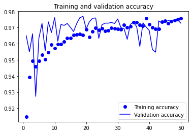

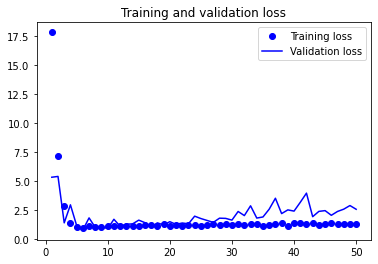

```python
# Plot the loss and accuracy of the model over the training and validation data during training.
accuracy = history.history['accuracy']
val_accuracy = history.history['val_accuracy']
loss = history.history['loss']
val_loss = history.history['val_loss']
epochs = range(1, len(accuracy) + 1)
plt.plot(epochs, accuracy, 'bo', label='Training accuracy')
plt.plot(epochs, val_accuracy, 'b', label='Validation accuracy')
plt.title('Training and validation accuracy')
plt.legend()
plt.figure()
plt.plot(epochs, loss, 'bo', label='Training loss')
plt.plot(epochs, val_loss, 'b', label='Validation loss')
plt.title('Training and validation loss')
plt.legend()
plt.show()
```

Now let's load in our best model and check its accuracy.

```python
# Display the accuracy of the model on the test dataset
model = keras.models.load_model('models/full_model.keras')
test_loss, test_acc = model.evaluate(test_dataset)
print('Test accuracy: %.3f' % (test_acc,))
```

```
Test accuracy: 0.973
```

## Fine Tuning a Pretrained Model

Fine-tuning consists of unfreezing a few of the top layers of a frozen model base used for feature extraction, and jointly training both the newly added part of the model (in this case, the fully connected classifier) and these top layers. This is called fine-tuning because it slightly adjusts the more abstract representations of the model being reused, in order to make them more relevant for the problem at hand.

Note that it’s only possible to fine-tune the top layers of the convolutional base once the classifier on top has already been trained. If the classifier isn’t already trained, then the error signal propagating through the network during training will be too large, and the representations previously learned by the layers being fine-tuned will be destroyed.

```python
# Unfreeze the top four layers
conv_base.trainable = True
for layer in conv_base.layers[:-4]:
  layer.trainable = False
```

Since we modified the model, we must recompile it for the changes to take hold. Also, since we are fine tuning now, we want to use a very small learning rate.

```python
# Recompile the model (since we changed the trainable layers)
model.compile(loss='binary_crossentropy',
              optimizer=keras.optimizers.RMSprop(learning_rate=1e-5),
              metrics=['accuracy'])
```

```python
# Define callbacks again, with a new save file
callbacks = [keras.callbacks.ModelCheckpoint(
    filepath='models/full_model_with_fine_tuning.keras',
    save_best_only=True,
    monitor='val_loss')]
```

```python
start_time = time.time()

history = model.fit(
    train_dataset,
    epochs=50,
    validation_data=validation_dataset,
    callbacks=callbacks)

print("--- Model trained in %s seconds ---" % (time.time() - start_time))
```

```
--- Model trained in 5223.628618478775 seconds ---
```

```python
# Display the accuracy of the model on the test dataset
model = keras.models.load_model('models/full_model_with_fine_tuning.keras')
test_loss, test_acc = model.evaluate(test_dataset)
print('Test accuracy: %.3f' % (test_acc,))
```

```
Test accuracy: 0.975
```

## Results

Through using the full dataset, and leveraging a pretrained model, we are able to achieve 97.5% accuracy, which I must say is pretty impressive.